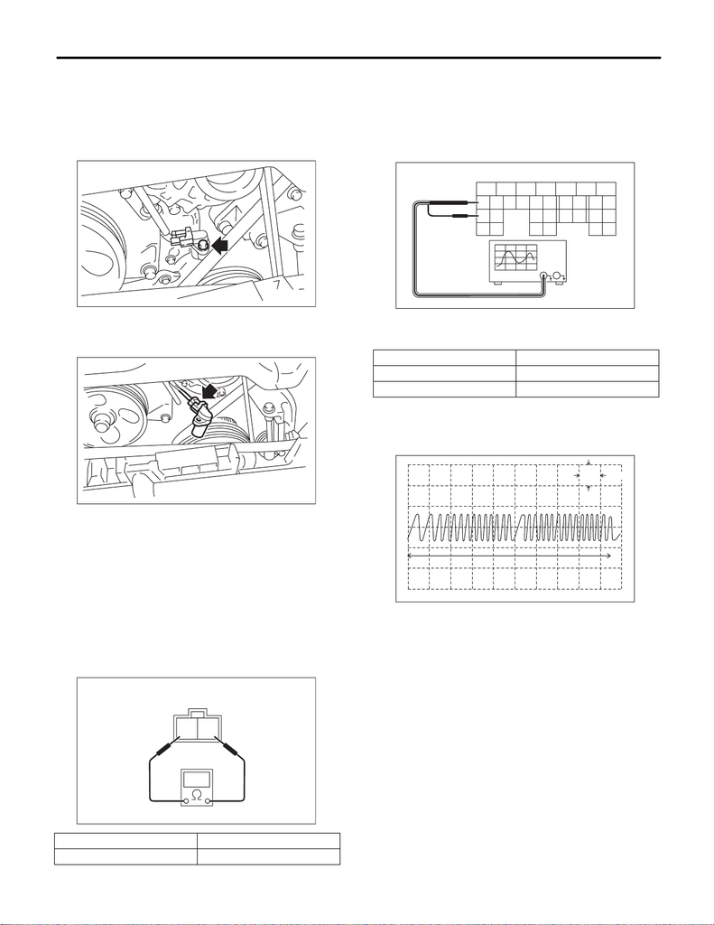

FU(STI)-34

Crankshaft Position Sensor

FUEL INJECTION (FUEL SYSTEMS)

5. Crankshaft Position Sensor

A: REMOVAL

1) Disconnect the ground cable from battery.

2) Remove the bolt which secures crankshaft posi-

tion sensor to oil pump.

3) Remove the crankshaft position sensor, and dis-

connect the connector from the crankshaft position

sensor.

B: INSTALLATION

Install in the reverse order of removal.

Tightening torque:

6.4 N·m (0.7 kgf-m, 4.7 ft-lb)

C: INSPECTION

1. CRANKSHAFT POSITION SENSOR

(METHOD WITH CIRCUIT TESTER)

Measure the resistance between crankshaft posi-

tion sensor terminals.

2. CRANKSHAFT POSITION SENSOR

(METHOD WITH OSCILLOSCOPE)

1) Prepare an oscilloscope.

2) Remove the glove box. <Ref. to EI-63, REMOV-

AL, Glove Box.>

3) Connect the probe to ECM connector.

4) Start the engine and let it idle.

5) Check the pattern is the same as the waveform

and voltage shown below.

6) After inspection, install the related parts in the

reverse order of removal.

3. OTHER INSPECTIONS

Check that the crankshaft position sensor has no

deformation, cracks or other damages.

Terminal No. Standard

1 and 2 2.04±0.204 kΩ

FU-05818

FU-05348

2

1

EC-02428

(A) To ECM connector

Terminal No. Probe

17 +

25 –

(A) One crankshaft rotation

8

21

9

10

26

FU-04758

(A)

FU-04057

5V

0

10ms

(A)